# Risk Factor Analysis

## Outcome Variable

**Outcome Variable:** whz

## Predictor Variables

**Intervention Variable:** parity

**Adjustment Set:**

unadjusted

## Stratifying Variables

The analysis was stratified on these variable(s):

- agecat
- studyid
- country

## Data Summary

| agecat | studyid | country | parity | n_cell | n |
| --- | --- | --- | --- | --- | --- |
| Birth | COHORTS | GUATEMALA | 1 | 94 | 756 |
| Birth | COHORTS | GUATEMALA | 2 | 118 | 756 |
| Birth | COHORTS | GUATEMALA | 3+ | 544 | 756 |
| Birth | COHORTS | INDIA | 1 | 641 | 3855 |
| Birth | COHORTS | INDIA | 2 | 982 | 3855 |
| Birth | COHORTS | INDIA | 3+ | 2232 | 3855 |
| Birth | COHORTS | PHILIPPINES | 1 | 640 | 2899 |
| Birth | COHORTS | PHILIPPINES | 2 | 657 | 2899 |
| Birth | COHORTS | PHILIPPINES | 3+ | 1602 | 2899 |
| Birth | GMS-Nepal | NEPAL | 1 | 185 | 641 |
| Birth | GMS-Nepal | NEPAL | 2 | 169 | 641 |
| Birth | GMS-Nepal | NEPAL | 3+ | 287 | 641 |
| Birth | Keneba | GAMBIA | 1 | 146 | 1338 |
| Birth | Keneba | GAMBIA | 2 | 142 | 1338 |
| Birth | Keneba | GAMBIA | 3+ | 1050 | 1338 |
| Birth | PROVIDE | BANGLADESH | 1 | 202 | 532 |
| Birth | PROVIDE | BANGLADESH | 2 | 182 | 532 |
| Birth | PROVIDE | BANGLADESH | 3+ | 148 | 532 |
| Birth | SAS-CompFeed | INDIA | 1 | 304 | 1103 |
| Birth | SAS-CompFeed | INDIA | 2 | 258 | 1103 |
| Birth | SAS-CompFeed | INDIA | 3+ | 541 | 1103 |
| Birth | ZVITAMBO | ZIMBABWE | 1 | 5561 | 12916 |
| Birth | ZVITAMBO | ZIMBABWE | 2 | 3882 | 12916 |
| Birth | ZVITAMBO | ZIMBABWE | 3+ | 3473 | 12916 |
| 6 months | COHORTS | GUATEMALA | 1 | 132 | 963 |
| 6 months | COHORTS | GUATEMALA | 2 | 139 | 963 |
| 6 months | COHORTS | GUATEMALA | 3+ | 692 | 963 |
| 6 months | COHORTS | INDIA | 1 | 741 | 4285 |
| 6 months | COHORTS | INDIA | 2 | 1093 | 4285 |
| 6 months | COHORTS | INDIA | 3+ | 2451 | 4285 |
| 6 months | COHORTS | PHILIPPINES | 1 | 574 | 2706 |
| 6 months | COHORTS | PHILIPPINES | 2 | 607 | 2706 |
| 6 months | COHORTS | PHILIPPINES | 3+ | 1525 | 2706 |
| 6 months | GMS-Nepal | NEPAL | 1 | 153 | 564 |
| 6 months | GMS-Nepal | NEPAL | 2 | 149 | 564 |
| 6 months | GMS-Nepal | NEPAL | 3+ | 262 | 564 |
| 6 months | Keneba | GAMBIA | 1 | 195 | 1623 |
| 6 months | Keneba | GAMBIA | 2 | 164 | 1623 |
| 6 months | Keneba | GAMBIA | 3+ | 1264 | 1623 |
| 6 months | PROVIDE | BANGLADESH | 1 | 218 | 603 |
| 6 months | PROVIDE | BANGLADESH | 2 | 222 | 603 |
| 6 months | PROVIDE | BANGLADESH | 3+ | 163 | 603 |
| 6 months | SAS-CompFeed | INDIA | 1 | 392 | 1334 |
| 6 months | SAS-CompFeed | INDIA | 2 | 302 | 1334 |
| 6 months | SAS-CompFeed | INDIA | 3+ | 640 | 1334 |
| 6 months | SAS-FoodSuppl | INDIA | 1 | 7 | 380 |
| 6 months | SAS-FoodSuppl | INDIA | 2 | 72 | 380 |
| 6 months | SAS-FoodSuppl | INDIA | 3+ | 301 | 380 |
| 6 months | TanzaniaChild2 | TANZANIA, UNITED REPUBLIC OF | 1 | 679 | 1994 |
| 6 months | TanzaniaChild2 | TANZANIA, UNITED REPUBLIC OF | 2 | 657 | 1994 |
| 6 months | TanzaniaChild2 | TANZANIA, UNITED REPUBLIC OF | 3+ | 658 | 1994 |
| 6 months | ZVITAMBO | ZIMBABWE | 1 | 3392 | 8504 |
| 6 months | ZVITAMBO | ZIMBABWE | 2 | 2587 | 8504 |
| 6 months | ZVITAMBO | ZIMBABWE | 3+ | 2525 | 8504 |
| 24 months | COHORTS | GUATEMALA | 1 | 167 | 1076 |
| 24 months | COHORTS | GUATEMALA | 2 | 151 | 1076 |
| 24 months | COHORTS | GUATEMALA | 3+ | 758 | 1076 |
| 24 months | COHORTS | INDIA | 1 | 561 | 3354 |
| 24 months | COHORTS | INDIA | 2 | 837 | 3354 |
| 24 months | COHORTS | INDIA | 3+ | 1956 | 3354 |
| 24 months | COHORTS | PHILIPPINES | 1 | 523 | 2449 |
| 24 months | COHORTS | PHILIPPINES | 2 | 544 | 2449 |
| 24 months | COHORTS | PHILIPPINES | 3+ | 1382 | 2449 |
| 24 months | GMS-Nepal | NEPAL | 1 | 130 | 487 |
| 24 months | GMS-Nepal | NEPAL | 2 | 130 | 487 |
| 24 months | GMS-Nepal | NEPAL | 3+ | 227 | 487 |
| 24 months | Keneba | GAMBIA | 1 | 137 | 1376 |
| 24 months | Keneba | GAMBIA | 2 | 139 | 1376 |
| 24 months | Keneba | GAMBIA | 3+ | 1100 | 1376 |
| 24 months | PROVIDE | BANGLADESH | 1 | 211 | 579 |
| 24 months | PROVIDE | BANGLADESH | 2 | 213 | 579 |
| 24 months | PROVIDE | BANGLADESH | 3+ | 155 | 579 |
| 24 months | TanzaniaChild2 | TANZANIA, UNITED REPUBLIC OF | 1 | 1 | 6 |
| 24 months | TanzaniaChild2 | TANZANIA, UNITED REPUBLIC OF | 2 | 1 | 6 |
| 24 months | TanzaniaChild2 | TANZANIA, UNITED REPUBLIC OF | 3+ | 4 | 6 |
| 24 months | ZVITAMBO | ZIMBABWE | 1 | 161 | 432 |
| 24 months | ZVITAMBO | ZIMBABWE | 2 | 123 | 432 |
| 24 months | ZVITAMBO | ZIMBABWE | 3+ | 148 | 432 |

The following strata were considered:

- agecat: 24 months, studyid: COHORTS, country: GUATEMALA
- agecat: 24 months, studyid: COHORTS, country: INDIA
- agecat: 24 months, studyid: COHORTS, country: PHILIPPINES
- agecat: 24 months, studyid: GMS-Nepal, country: NEPAL
- agecat: 24 months, studyid: Keneba, country: GAMBIA
- agecat: 24 months, studyid: PROVIDE, country: BANGLADESH
- agecat: 24 months, studyid: TanzaniaChild2, country: TANZANIA, UNITED REPUBLIC OF
- agecat: 24 months, studyid: ZVITAMBO, country: ZIMBABWE
- agecat: 6 months, studyid: COHORTS, country: GUATEMALA
- agecat: 6 months, studyid: COHORTS, country: INDIA
- agecat: 6 months, studyid: COHORTS, country: PHILIPPINES
- agecat: 6 months, studyid: GMS-Nepal, country: NEPAL
- agecat: 6 months, studyid: Keneba, country: GAMBIA
- agecat: 6 months, studyid: PROVIDE, country: BANGLADESH
- agecat: 6 months, studyid: SAS-CompFeed, country: INDIA
- agecat: 6 months, studyid: SAS-FoodSuppl, country: INDIA
- agecat: 6 months, studyid: TanzaniaChild2, country: TANZANIA, UNITED REPUBLIC OF
- agecat: 6 months, studyid: ZVITAMBO, country: ZIMBABWE
- agecat: Birth, studyid: COHORTS, country: GUATEMALA
- agecat: Birth, studyid: COHORTS, country: INDIA
- agecat: Birth, studyid: COHORTS, country: PHILIPPINES
- agecat: Birth, studyid: GMS-Nepal, country: NEPAL
- agecat: Birth, studyid: Keneba, country: GAMBIA
- agecat: Birth, studyid: PROVIDE, country: BANGLADESH
- agecat: Birth, studyid: SAS-CompFeed, country: INDIA
- agecat: Birth, studyid: ZVITAMBO, country: ZIMBABWE

### Dropped Strata

Some strata were dropped due to rare outcomes:

- agecat: 24 months, studyid: TanzaniaChild2, country: TANZANIA, UNITED REPUBLIC OF

## Methods Detail

We’re interested in the causal parameters $E[Y_a]$ for all values of $a \in \mathcal{A}$. These parameters represent the mean outcome if, possibly contrary to fact, we intervened to set all units to have $A=a$. Under the randomization and positivity assumptions, these are identified by the statistical parameters $\psi_a=E_W[E_{Y|A,W}(Y|A=a,W)]$. In addition, we’re interested in the mean of $Y$, $E[Y]$ under no intervention (the observed mean). We will estimate these parameters by using SuperLearner to fit the relevant likelihood factors – $E_{Y|A,W}(Y|A=a,W)$ and $p(A=a|W)$, and then updating our likelihood fit using a joint TMLE.

For unadjusted analyses ($W=\{\}$), initial likelihoods were estimated using Lrnr_glm to estimate the simple $E(Y|A)$ and Lrnr_mean to estimate $p(A)$. For adjusted analyses, a small library containing Lrnr_glmnet, Lrnr_xgboost, and Lrnr_mean was used.

Having estimated these parameters, we will then use the delta method to estimate relative risks and attributable risks relative to a prespecified baseline level of $A$.

# Results Detail

## Results Plots

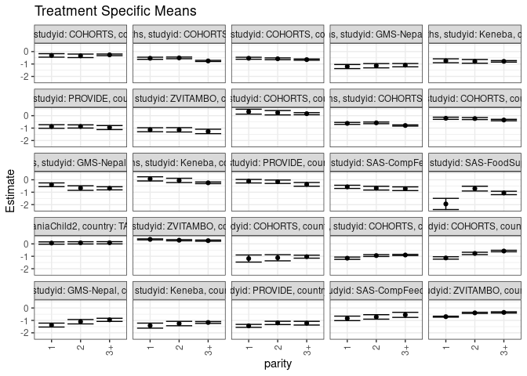

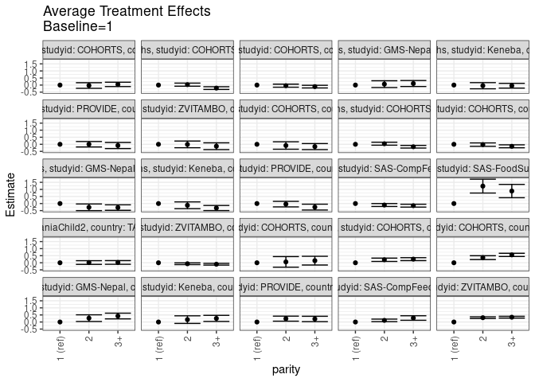

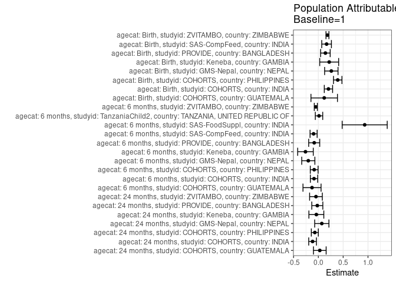

## Results Table

### Parameter: TSM

| agecat | studyid | country | intervention_level | baseline_level | estimate | ci_lower | ci_upper |
| --- | --- | --- | --- | --- | --- | --- | --- |
| Birth | COHORTS | GUATEMALA | 1 | NA | -1.1797872 | -1.4650692 | -0.8945053 |
| Birth | COHORTS | GUATEMALA | 2 | NA | -1.1183898 | -1.3645589 | -0.8722208 |
| Birth | COHORTS | GUATEMALA | 3+ | NA | -1.0296140 | -1.1495677 | -0.9096603 |
| Birth | COHORTS | INDIA | 1 | NA | -1.1529953 | -1.2447465 | -1.0612441 |
| Birth | COHORTS | INDIA | 2 | NA | -0.9408961 | -1.0142407 | -0.8675516 |
| Birth | COHORTS | INDIA | 3+ | NA | -0.8953763 | -0.9449512 | -0.8458015 |
| Birth | COHORTS | PHILIPPINES | 1 | NA | -1.1326875 | -1.2287573 | -1.0366177 |
| Birth | COHORTS | PHILIPPINES | 2 | NA | -0.7699696 | -0.8650746 | -0.6748645 |
| Birth | COHORTS | PHILIPPINES | 3+ | NA | -0.5757615 | -0.6376536 | -0.5138695 |
| Birth | GMS-Nepal | NEPAL | 1 | NA | -1.3775676 | -1.5355116 | -1.2196235 |
| Birth | GMS-Nepal | NEPAL | 2 | NA | -1.1053254 | -1.2819550 | -0.9286959 |
| Birth | GMS-Nepal | NEPAL | 3+ | NA | -0.9546690 | -1.0816685 | -0.8276695 |
| Birth | Keneba | GAMBIA | 1 | NA | -1.4217808 | -1.6242015 | -1.2193602 |
| Birth | Keneba | GAMBIA | 2 | NA | -1.2536972 | -1.4306707 | -1.0767237 |
| Birth | Keneba | GAMBIA | 3+ | NA | -1.1666429 | -1.2415680 | -1.0917177 |
| Birth | PROVIDE | BANGLADESH | 1 | NA | -1.4397030 | -1.5586731 | -1.3207328 |
| Birth | PROVIDE | BANGLADESH | 2 | NA | -1.2023077 | -1.3345758 | -1.0700396 |
| Birth | PROVIDE | BANGLADESH | 3+ | NA | -1.2239189 | -1.3731656 | -1.0746722 |
| Birth | SAS-CompFeed | INDIA | 1 | NA | -0.8356250 | -1.0165469 | -0.6547031 |
| Birth | SAS-CompFeed | INDIA | 2 | NA | -0.7208527 | -0.9011044 | -0.5406010 |
| Birth | SAS-CompFeed | INDIA | 3+ | NA | -0.5527726 | -0.7556552 | -0.3498901 |
| Birth | ZVITAMBO | ZIMBABWE | 1 | NA | -0.6987448 | -0.7379920 | -0.6594976 |
| Birth | ZVITAMBO | ZIMBABWE | 2 | NA | -0.3937635 | -0.4405965 | -0.3469305 |
| Birth | ZVITAMBO | ZIMBABWE | 3+ | NA | -0.3586611 | -0.4081957 | -0.3091265 |
| 6 months | COHORTS | GUATEMALA | 1 | NA | 0.3220455 | 0.1254142 | 0.5186767 |
| 6 months | COHORTS | GUATEMALA | 2 | NA | 0.2369065 | 0.0615093 | 0.4123036 |
| 6 months | COHORTS | GUATEMALA | 3+ | NA | 0.1610694 | 0.0761466 | 0.2459922 |
| 6 months | COHORTS | INDIA | 1 | NA | -0.6192443 | -0.6996552 | -0.5388334 |
| 6 months | COHORTS | INDIA | 2 | NA | -0.5773193 | -0.6450617 | -0.5095769 |
| 6 months | COHORTS | INDIA | 3+ | NA | -0.7911179 | -0.8379869 | -0.7442489 |
| 6 months | COHORTS | PHILIPPINES | 1 | NA | -0.2095296 | -0.2972306 | -0.1218286 |
| 6 months | COHORTS | PHILIPPINES | 2 | NA | -0.2310049 | -0.3121896 | -0.1498203 |
| 6 months | COHORTS | PHILIPPINES | 3+ | NA | -0.3505902 | -0.4074607 | -0.2937196 |
| 6 months | GMS-Nepal | NEPAL | 1 | NA | -0.4010131 | -0.5499696 | -0.2520566 |
| 6 months | GMS-Nepal | NEPAL | 2 | NA | -0.6667114 | -0.8478886 | -0.4855342 |
| 6 months | GMS-Nepal | NEPAL | 3+ | NA | -0.6865331 | -0.8117770 | -0.5612891 |
| 6 months | Keneba | GAMBIA | 1 | NA | 0.0725031 | -0.0950835 | 0.2400898 |
| 6 months | Keneba | GAMBIA | 2 | NA | -0.0518201 | -0.2242735 | 0.1206332 |
| 6 months | Keneba | GAMBIA | 3+ | NA | -0.2450740 | -0.3112601 | -0.1788880 |
| 6 months | PROVIDE | BANGLADESH | 1 | NA | -0.1151911 | -0.2565373 | 0.0261550 |
| 6 months | PROVIDE | BANGLADESH | 2 | NA | -0.1572748 | -0.2933764 | -0.0211732 |
| 6 months | PROVIDE | BANGLADESH | 3+ | NA | -0.3682515 | -0.5184596 | -0.2180435 |
| 6 months | SAS-CompFeed | INDIA | 1 | NA | -0.5695281 | -0.6974230 | -0.4416331 |
| 6 months | SAS-CompFeed | INDIA | 2 | NA | -0.6747020 | -0.8267292 | -0.5226748 |
| 6 months | SAS-CompFeed | INDIA | 3+ | NA | -0.7203750 | -0.8706403 | -0.5701097 |
| 6 months | SAS-FoodSuppl | INDIA | 1 | NA | -1.9457143 | -2.3960187 | -1.4954099 |
| 6 months | SAS-FoodSuppl | INDIA | 2 | NA | -0.7120833 | -0.9054564 | -0.5187103 |
| 6 months | SAS-FoodSuppl | INDIA | 3+ | NA | -1.0622259 | -1.1982227 | -0.9262292 |
| 6 months | TanzaniaChild2 | TANZANIA, UNITED REPUBLIC OF | 1 | NA | 0.0667796 | -0.0263353 | 0.1598944 |
| 6 months | TanzaniaChild2 | TANZANIA, UNITED REPUBLIC OF | 2 | NA | 0.0835908 | -0.0083426 | 0.1755242 |
| 6 months | TanzaniaChild2 | TANZANIA, UNITED REPUBLIC OF | 3+ | NA | 0.0892021 | -0.0012958 | 0.1797001 |
| 6 months | ZVITAMBO | ZIMBABWE | 1 | NA | 0.3616952 | 0.3223175 | 0.4010728 |
| 6 months | ZVITAMBO | ZIMBABWE | 2 | NA | 0.2933475 | 0.2456532 | 0.3410418 |
| 6 months | ZVITAMBO | ZIMBABWE | 3+ | NA | 0.2597822 | 0.2120045 | 0.3075599 |
| 24 months | COHORTS | GUATEMALA | 1 | NA | -0.3101796 | -0.4498621 | -0.1704972 |
| 24 months | COHORTS | GUATEMALA | 2 | NA | -0.3416556 | -0.4820595 | -0.2012518 |
| 24 months | COHORTS | GUATEMALA | 3+ | NA | -0.2630211 | -0.3275210 | -0.1985212 |
| 24 months | COHORTS | INDIA | 1 | NA | -0.5394474 | -0.6242759 | -0.4546189 |
| 24 months | COHORTS | INDIA | 2 | NA | -0.5091398 | -0.5771205 | -0.4411590 |
| 24 months | COHORTS | INDIA | 3+ | NA | -0.7530828 | -0.7990574 | -0.7071083 |
| 24 months | COHORTS | PHILIPPINES | 1 | NA | -0.5384895 | -0.6177702 | -0.4592088 |
| 24 months | COHORTS | PHILIPPINES | 2 | NA | -0.5811765 | -0.6541762 | -0.5081768 |
| 24 months | COHORTS | PHILIPPINES | 3+ | NA | -0.6483357 | -0.6984875 | -0.5981840 |
| 24 months | GMS-Nepal | NEPAL | 1 | NA | -1.2054872 | -1.3701523 | -1.0408220 |
| 24 months | GMS-Nepal | NEPAL | 2 | NA | -1.1389231 | -1.3120878 | -0.9657584 |
| 24 months | GMS-Nepal | NEPAL | 3+ | NA | -1.0951982 | -1.2279806 | -0.9624159 |
| 24 months | Keneba | GAMBIA | 1 | NA | -0.7427859 | -0.9002662 | -0.5853056 |
| 24 months | Keneba | GAMBIA | 2 | NA | -0.7875995 | -0.9380261 | -0.6371730 |
| 24 months | Keneba | GAMBIA | 3+ | NA | -0.7879374 | -0.8474705 | -0.7284044 |
| 24 months | PROVIDE | BANGLADESH | 1 | NA | -0.8713507 | -1.0145879 | -0.7281136 |
| 24 months | PROVIDE | BANGLADESH | 2 | NA | -0.8677700 | -0.9959631 | -0.7395768 |
| 24 months | PROVIDE | BANGLADESH | 3+ | NA | -0.9566452 | -1.1182734 | -0.7950170 |
| 24 months | ZVITAMBO | ZIMBABWE | 1 | NA | -1.1334161 | -1.2935830 | -0.9732493 |
| 24 months | ZVITAMBO | ZIMBABWE | 2 | NA | -1.1402439 | -1.3148753 | -0.9656125 |
| 24 months | ZVITAMBO | ZIMBABWE | 3+ | NA | -1.2689189 | -1.4478586 | -1.0899793 |

### Parameter: E(Y)

| agecat | studyid | country | intervention_level | baseline_level | estimate | ci_lower | ci_upper |
| --- | --- | --- | --- | --- | --- | --- | --- |
| Birth | COHORTS | GUATEMALA | NA | NA | -1.0621429 | -1.1631387 | -0.9611471 |
| Birth | COHORTS | INDIA | NA | NA | -0.9498080 | -0.9874148 | -0.9122013 |
| Birth | COHORTS | PHILIPPINES | NA | NA | -0.7427251 | -0.7890855 | -0.6963647 |
| Birth | GMS-Nepal | NEPAL | NA | NA | -1.1164431 | -1.2040134 | -1.0288728 |
| Birth | Keneba | GAMBIA | NA | NA | -1.2037220 | -1.2694226 | -1.1380213 |
| Birth | PROVIDE | BANGLADESH | NA | NA | -1.2984586 | -1.3752758 | -1.2216415 |
| Birth | SAS-CompFeed | INDIA | NA | NA | -0.6700453 | -0.8474950 | -0.4925957 |
| Birth | ZVITAMBO | ZIMBABWE | NA | NA | -0.5156349 | -0.5414936 | -0.4897762 |
| 6 months | COHORTS | GUATEMALA | NA | NA | 0.1940810 | 0.1226351 | 0.2655269 |
| 6 months | COHORTS | INDIA | NA | NA | -0.7068611 | -0.7417800 | -0.6719423 |
| 6 months | COHORTS | PHILIPPINES | NA | NA | -0.2938433 | -0.3352064 | -0.2524802 |
| 6 months | GMS-Nepal | NEPAL | NA | NA | -0.6038416 | -0.6899448 | -0.5177384 |
| 6 months | Keneba | GAMBIA | NA | NA | -0.1873900 | -0.2456638 | -0.1291162 |
| 6 months | PROVIDE | BANGLADESH | NA | NA | -0.1990907 | -0.2817968 | -0.1163845 |
| 6 months | SAS-CompFeed | INDIA | NA | NA | -0.6657084 | -0.8024377 | -0.5289791 |
| 6 months | SAS-FoodSuppl | INDIA | NA | NA | -1.0121579 | -1.1280429 | -0.8962729 |
| 6 months | TanzaniaChild2 | TANZANIA, UNITED REPUBLIC OF | NA | NA | 0.0797179 | 0.0266621 | 0.1327737 |
| 6 months | ZVITAMBO | ZIMBABWE | NA | NA | 0.3106432 | 0.2849661 | 0.3363203 |
| 24 months | COHORTS | GUATEMALA | NA | NA | -0.2813755 | -0.3354674 | -0.2272835 |
| 24 months | COHORTS | INDIA | NA | NA | -0.6564729 | -0.6914450 | -0.6215007 |
| 24 months | COHORTS | PHILIPPINES | NA | NA | -0.6099592 | -0.6467541 | -0.5731643 |
| 24 months | GMS-Nepal | NEPAL | NA | NA | -1.1363107 | -1.2252817 | -1.0473398 |
| 24 months | Keneba | GAMBIA | NA | NA | -0.7834078 | -0.8357743 | -0.7310414 |
| 24 months | PROVIDE | BANGLADESH | NA | NA | -0.8928670 | -0.9755153 | -0.8102187 |
| 24 months | ZVITAMBO | ZIMBABWE | NA | NA | -1.1817824 | -1.2809226 | -1.0826422 |

### Parameter: ATE

| agecat | studyid | country | intervention_level | baseline_level | estimate | ci_lower | ci_upper |
| --- | --- | --- | --- | --- | --- | --- | --- |
| Birth | COHORTS | GUATEMALA | 1 | 1 | 0.0000000 | 0.0000000 | 0.0000000 |
| Birth | COHORTS | GUATEMALA | 2 | 1 | 0.0613974 | -0.3154116 | 0.4382064 |
| Birth | COHORTS | GUATEMALA | 3+ | 1 | 0.1501733 | -0.1593016 | 0.4596481 |
| Birth | COHORTS | INDIA | 1 | 1 | 0.0000000 | 0.0000000 | 0.0000000 |
| Birth | COHORTS | INDIA | 2 | 1 | 0.2120992 | 0.0946355 | 0.3295628 |
| Birth | COHORTS | INDIA | 3+ | 1 | 0.2576190 | 0.1533312 | 0.3619068 |
| Birth | COHORTS | PHILIPPINES | 1 | 1 | 0.0000000 | 0.0000000 | 0.0000000 |
| Birth | COHORTS | PHILIPPINES | 2 | 1 | 0.3627179 | 0.2275351 | 0.4979007 |
| Birth | COHORTS | PHILIPPINES | 3+ | 1 | 0.5569260 | 0.4426454 | 0.6712065 |
| Birth | GMS-Nepal | NEPAL | 1 | 1 | 0.0000000 | 0.0000000 | 0.0000000 |
| Birth | GMS-Nepal | NEPAL | 2 | 1 | 0.2722421 | 0.0352942 | 0.5091900 |
| Birth | GMS-Nepal | NEPAL | 3+ | 1 | 0.4228986 | 0.2202284 | 0.6255687 |
| Birth | Keneba | GAMBIA | 1 | 1 | 0.0000000 | 0.0000000 | 0.0000000 |
| Birth | Keneba | GAMBIA | 2 | 1 | 0.1680836 | -0.1007913 | 0.4369586 |
| Birth | Keneba | GAMBIA | 3+ | 1 | 0.2551380 | 0.0392957 | 0.4709803 |
| Birth | PROVIDE | BANGLADESH | 1 | 1 | 0.0000000 | 0.0000000 | 0.0000000 |
| Birth | PROVIDE | BANGLADESH | 2 | 1 | 0.2373953 | 0.0594943 | 0.4152962 |
| Birth | PROVIDE | BANGLADESH | 3+ | 1 | 0.2157841 | 0.0249216 | 0.4066465 |
| Birth | SAS-CompFeed | INDIA | 1 | 1 | 0.0000000 | 0.0000000 | 0.0000000 |
| Birth | SAS-CompFeed | INDIA | 2 | 1 | 0.1147723 | 0.0243566 | 0.2051880 |
| Birth | SAS-CompFeed | INDIA | 3+ | 1 | 0.2828524 | 0.1234266 | 0.4422781 |
| Birth | ZVITAMBO | ZIMBABWE | 1 | 1 | 0.0000000 | 0.0000000 | 0.0000000 |
| Birth | ZVITAMBO | ZIMBABWE | 2 | 1 | 0.3049813 | 0.2438775 | 0.3660851 |
| Birth | ZVITAMBO | ZIMBABWE | 3+ | 1 | 0.3400837 | 0.2768855 | 0.4032820 |
| 6 months | COHORTS | GUATEMALA | 1 | 1 | 0.0000000 | 0.0000000 | 0.0000000 |
| 6 months | COHORTS | GUATEMALA | 2 | 1 | -0.0851390 | -0.3486310 | 0.1783530 |
| 6 months | COHORTS | GUATEMALA | 3+ | 1 | -0.1609761 | -0.3751623 | 0.0532101 |
| 6 months | COHORTS | INDIA | 1 | 1 | 0.0000000 | 0.0000000 | 0.0000000 |
| 6 months | COHORTS | INDIA | 2 | 1 | 0.0419250 | -0.0632175 | 0.1470674 |
| 6 months | COHORTS | INDIA | 3+ | 1 | -0.1718736 | -0.2649468 | -0.0788005 |
| 6 months | COHORTS | PHILIPPINES | 1 | 1 | 0.0000000 | 0.0000000 | 0.0000000 |
| 6 months | COHORTS | PHILIPPINES | 2 | 1 | -0.0214753 | -0.1409844 | 0.0980337 |
| 6 months | COHORTS | PHILIPPINES | 3+ | 1 | -0.1410605 | -0.2455867 | -0.0365344 |
| 6 months | GMS-Nepal | NEPAL | 1 | 1 | 0.0000000 | 0.0000000 | 0.0000000 |
| 6 months | GMS-Nepal | NEPAL | 2 | 1 | -0.2656983 | -0.5002473 | -0.0311494 |
| 6 months | GMS-Nepal | NEPAL | 3+ | 1 | -0.2855200 | -0.4801327 | -0.0909073 |
| 6 months | Keneba | GAMBIA | 1 | 1 | 0.0000000 | 0.0000000 | 0.0000000 |
| 6 months | Keneba | GAMBIA | 2 | 1 | -0.1243233 | -0.3647925 | 0.1161459 |
| 6 months | Keneba | GAMBIA | 3+ | 1 | -0.3175772 | -0.4977600 | -0.1373943 |
| 6 months | PROVIDE | BANGLADESH | 1 | 1 | 0.0000000 | 0.0000000 | 0.0000000 |
| 6 months | PROVIDE | BANGLADESH | 2 | 1 | -0.0420836 | -0.2383039 | 0.1541366 |
| 6 months | PROVIDE | BANGLADESH | 3+ | 1 | -0.2530604 | -0.4593156 | -0.0468052 |
| 6 months | SAS-CompFeed | INDIA | 1 | 1 | 0.0000000 | 0.0000000 | 0.0000000 |
| 6 months | SAS-CompFeed | INDIA | 2 | 1 | -0.1051739 | -0.2086042 | -0.0017436 |
| 6 months | SAS-CompFeed | INDIA | 3+ | 1 | -0.1508469 | -0.2528162 | -0.0488777 |
| 6 months | SAS-FoodSuppl | INDIA | 1 | 1 | 0.0000000 | 0.0000000 | 0.0000000 |
| 6 months | SAS-FoodSuppl | INDIA | 2 | 1 | 1.2336310 | 0.7435624 | 1.7236995 |
| 6 months | SAS-FoodSuppl | INDIA | 3+ | 1 | 0.8834884 | 0.4130958 | 1.3538809 |
| 6 months | TanzaniaChild2 | TANZANIA, UNITED REPUBLIC OF | 1 | 1 | 0.0000000 | 0.0000000 | 0.0000000 |
| 6 months | TanzaniaChild2 | TANZANIA, UNITED REPUBLIC OF | 2 | 1 | 0.0168112 | -0.1140403 | 0.1476628 |
| 6 months | TanzaniaChild2 | TANZANIA, UNITED REPUBLIC OF | 3+ | 1 | 0.0224225 | -0.1074245 | 0.1522696 |
| 6 months | ZVITAMBO | ZIMBABWE | 1 | 1 | 0.0000000 | 0.0000000 | 0.0000000 |
| 6 months | ZVITAMBO | ZIMBABWE | 2 | 1 | -0.0683477 | -0.1301970 | -0.0064983 |
| 6 months | ZVITAMBO | ZIMBABWE | 3+ | 1 | -0.1019130 | -0.1638267 | -0.0399993 |
| 24 months | COHORTS | GUATEMALA | 1 | 1 | 0.0000000 | 0.0000000 | 0.0000000 |
| 24 months | COHORTS | GUATEMALA | 2 | 1 | -0.0314760 | -0.2295276 | 0.1665756 |
| 24 months | COHORTS | GUATEMALA | 3+ | 1 | 0.0471585 | -0.1066967 | 0.2010138 |
| 24 months | COHORTS | INDIA | 1 | 1 | 0.0000000 | 0.0000000 | 0.0000000 |
| 24 months | COHORTS | INDIA | 2 | 1 | 0.0303076 | -0.0783996 | 0.1390148 |
| 24 months | COHORTS | INDIA | 3+ | 1 | -0.2136354 | -0.3101213 | -0.1171495 |
| 24 months | COHORTS | PHILIPPINES | 1 | 1 | 0.0000000 | 0.0000000 | 0.0000000 |
| 24 months | COHORTS | PHILIPPINES | 2 | 1 | -0.0426870 | -0.1504570 | 0.0650830 |
| 24 months | COHORTS | PHILIPPINES | 3+ | 1 | -0.1098463 | -0.2036579 | -0.0160346 |
| 24 months | GMS-Nepal | NEPAL | 1 | 1 | 0.0000000 | 0.0000000 | 0.0000000 |
| 24 months | GMS-Nepal | NEPAL | 2 | 1 | 0.0665641 | -0.1723933 | 0.3055215 |
| 24 months | GMS-Nepal | NEPAL | 3+ | 1 | 0.1102889 | -0.1012430 | 0.3218209 |
| 24 months | Keneba | GAMBIA | 1 | 1 | 0.0000000 | 0.0000000 | 0.0000000 |
| 24 months | Keneba | GAMBIA | 2 | 1 | -0.0448136 | -0.2625938 | 0.1729665 |
| 24 months | Keneba | GAMBIA | 3+ | 1 | -0.0451515 | -0.2135090 | 0.1232059 |
| 24 months | PROVIDE | BANGLADESH | 1 | 1 | 0.0000000 | 0.0000000 | 0.0000000 |
| 24 months | PROVIDE | BANGLADESH | 2 | 1 | 0.0035808 | -0.1886440 | 0.1958056 |
| 24 months | PROVIDE | BANGLADESH | 3+ | 1 | -0.0852945 | -0.3012587 | 0.1306698 |
| 24 months | ZVITAMBO | ZIMBABWE | 1 | 1 | 0.0000000 | 0.0000000 | 0.0000000 |
| 24 months | ZVITAMBO | ZIMBABWE | 2 | 1 | -0.0068278 | -0.2437867 | 0.2301312 |
| 24 months | ZVITAMBO | ZIMBABWE | 3+ | 1 | -0.1355028 | -0.3756544 | 0.1046489 |

### Parameter: PAR

| agecat | studyid | country | intervention_level | baseline_level | estimate | ci_lower | ci_upper |
| --- | --- | --- | --- | --- | --- | --- | --- |
| Birth | COHORTS | GUATEMALA | 1 | NA | 0.1176444 | -0.1494645 | 0.3847533 |
| Birth | COHORTS | INDIA | 1 | NA | 0.2031873 | 0.1193242 | 0.2870503 |
| Birth | COHORTS | PHILIPPINES | 1 | NA | 0.3899624 | 0.3045012 | 0.4754237 |
| Birth | GMS-Nepal | NEPAL | 1 | NA | 0.2611245 | 0.1261605 | 0.3960885 |
| Birth | Keneba | GAMBIA | 1 | NA | 0.2180588 | 0.0274056 | 0.4087121 |
| Birth | PROVIDE | BANGLADESH | 1 | NA | 0.1412443 | 0.0447751 | 0.2377136 |
| Birth | SAS-CompFeed | INDIA | 1 | NA | 0.1655797 | 0.0679520 | 0.2632074 |
| Birth | ZVITAMBO | ZIMBABWE | 1 | NA | 0.1831100 | 0.1534010 | 0.2128189 |
| 6 months | COHORTS | GUATEMALA | 1 | NA | -0.1279645 | -0.3100879 | 0.0541590 |
| 6 months | COHORTS | INDIA | 1 | NA | -0.0876169 | -0.1614339 | -0.0137999 |
| 6 months | COHORTS | PHILIPPINES | 1 | NA | -0.0843137 | -0.1626675 | -0.0059598 |
| 6 months | GMS-Nepal | NEPAL | 1 | NA | -0.2028285 | -0.3353563 | -0.0703008 |
| 6 months | Keneba | GAMBIA | 1 | NA | -0.2598931 | -0.4171583 | -0.1026280 |
| 6 months | PROVIDE | BANGLADESH | 1 | NA | -0.0838995 | -0.1951353 | 0.0273362 |
| 6 months | SAS-CompFeed | INDIA | 1 | NA | -0.0961803 | -0.1675004 | -0.0248602 |
| 6 months | SAS-FoodSuppl | INDIA | 1 | NA | 0.9335564 | 0.4796129 | 1.3874999 |
| 6 months | TanzaniaChild2 | TANZANIA, UNITED REPUBLIC OF | 1 | NA | 0.0129383 | -0.0617637 | 0.0876404 |
| 6 months | ZVITAMBO | ZIMBABWE | 1 | NA | -0.0510519 | -0.0822438 | -0.0198600 |
| 24 months | COHORTS | GUATEMALA | 1 | NA | 0.0288042 | -0.0991829 | 0.1567912 |
| 24 months | COHORTS | INDIA | 1 | NA | -0.1170255 | -0.1945607 | -0.0394902 |
| 24 months | COHORTS | PHILIPPINES | 1 | NA | -0.0714697 | -0.1418593 | -0.0010800 |
| 24 months | GMS-Nepal | NEPAL | 1 | NA | 0.0691764 | -0.0741919 | 0.2125448 |
| 24 months | Keneba | GAMBIA | 1 | NA | -0.0406219 | -0.1909679 | 0.1097240 |
| 24 months | PROVIDE | BANGLADESH | 1 | NA | -0.0215163 | -0.1328448 | 0.0898122 |
| 24 months | ZVITAMBO | ZIMBABWE | 1 | NA | -0.0483663 | -0.1762760 | 0.0795435 |